# Introduction to geospatial mapping in R

Author

Paul Magwene

## Libraries

Install the `sf` and `ggspatial` packages via R package manager.

```r
library(tidyverse)
library(patchwork)

library(sf)
library(ggspatial) # nice extras
```

## Data: Shapefile

We’re going to get data on country, state, and county boundaries from a website called [“Natural Earth”](https://www.naturalearthdata.com/). Natural Earth is a public domain map data set available at 3 different scales. The data is free to use and the development of Natural Earth is supported by the North American Cartographic Information Society.

The [downloads page on Natural Earth](https://www.naturalearthdata.com/downloads/) provides links to different types of features (cultural (political), physical, raster) at 3 different scales. We’ll use the [large scale cultural data (1:10m)](https://www.naturalearthdata.com/downloads/10m-cultural-vectors/).

Download and de-compress the zip files for:

- [Admin 0 - Countries](https://www.naturalearthdata.com/http//www.naturalearthdata.com/download/10m/cultural/ne_10m_admin_0_countries.zip)
- [Admin 1 – States, Provinces](https://www.naturalearthdata.com/http//www.naturalearthdata.com/download/10m/cultural/ne_10m_admin_1_states_provinces.zip)
- [Admin 2 – Counties](https://www.naturalearthdata.com/http//www.naturalearthdata.com/download/10m/cultural/ne_10m_admin_2_counties.zip)

Place the directories extracted from the zip files your working directory before proceeding. You should have the following three directories in your working directory:

1. `ne_10m_admin_0_countries`
2. `ne_10m_admin_1_states_provinces`
3. `ne_10m_admin_2_counties`

## Reading shape files

In the `sf` package, all function that operate on spatial data are prefixed by `st_` (referring to to spatial type).

The function to read a simple features file (or other common GIS data files) is `sf::st_read`. Let’s start by reading the Natural Earth countries file:

```r
countries <-
    st_read("ne_10m_admin_0_countries/ne_10m_admin_0_countries.shp")
```

## SF objects are data frames

```r
typeof(countries)
```

```
[1] "list"
```

```r
class(countries)
```

```
[1] "sf"         "data.frame"
```

```r
dim(countries)
```

```
[1] 258 169
```

## Where’s the geometry?

Look at the `countries` object in your data viewer. You’ll see lots of variables (columns) with some obvious and non-obvious meanings. The very last column is called “geometry”, and the values of this column are lists that represent the geometric objects of the mapping (country boundaries in this case)

## Querying simple features objects about the CRS

We can ask a simple features object about it’s coordinate reference system:

```r
st_crs(countries)
```

```
Coordinate Reference System:
  User input: WGS 84
  wkt:
GEOGCRS["WGS 84",
    DATUM["World Geodetic System 1984",
        ELLIPSOID["WGS 84",6378137,298.257223563,
            LENGTHUNIT["metre",1]]],
    PRIMEM["Greenwich",0,
        ANGLEUNIT["degree",0.0174532925199433]],
    CS[ellipsoidal,2],
        AXIS["latitude",north,
            ORDER[1],
            ANGLEUNIT["degree",0.0174532925199433]],
        AXIS["longitude",east,
            ORDER[2],
            ANGLEUNIT["degree",0.0174532925199433]],
    ID["EPSG",4326]]
```

## Mapping a simple features data frame

Mapping a data frame representing simple features data in ggplot is easy using the `geom_sf` object.

The default coordinate system used is WGS84 with a Mercator projection:

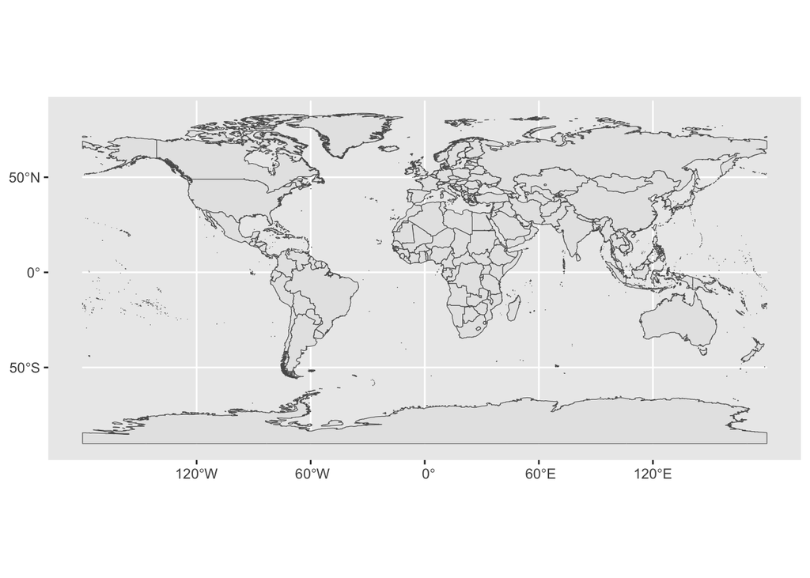

```r
ggplot() +
  geom_sf(data = countries)
```

## Creating an SF object on the fly

Let’s create a SF point object representing where Durham is on the map.

```r
# create a data frame with the latitude and longitude of durham
durham <- tibble(long = -78.9, lat = 36)
durham
```

```
# A tibble: 1 × 2
   long   lat
  <dbl> <dbl>
1 -78.9    36
```

Now convert that data frame to an `sf` object using `st_as_sf`, and specify the coordinate reference system:

```r
durham_sf <- st_as_sf(durham,
                      coords = c("long","lat"),
                      crs=4326)

durham_sf
```

```
Simple feature collection with 1 feature and 0 fields
Geometry type: POINT
Dimension:     XY
Bounding box:  xmin: -78.9 ymin: 36 xmax: -78.9 ymax: 36
Geodetic CRS:  WGS 84
# A tibble: 1 × 1
     geometry
* <POINT [°]>
1  (-78.9 36)
```

To plot this point data we can simply include it as another `geom_sf` layer:

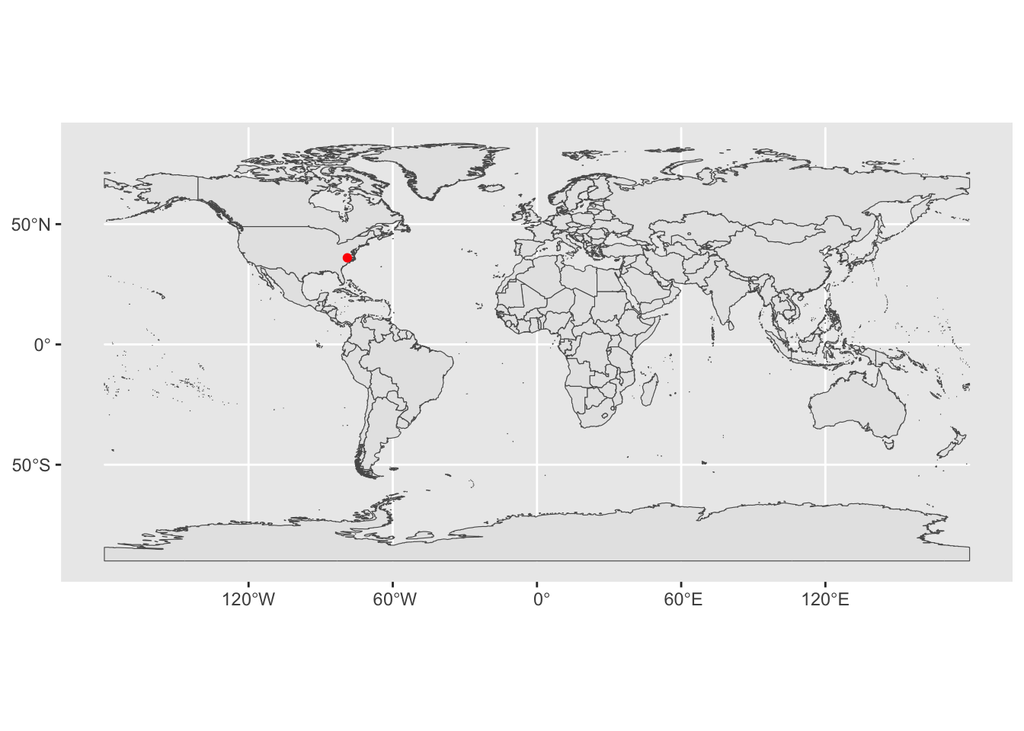

```r
ggplot() +
  geom_sf(data = countries) +
  geom_sf(data = durham_sf, color = "red")
```

## Mapping with a different CRS

If we want to use a different coordinate system we can specify that using the `coord_sf` function. Here we use [EPS:3035](https://spatialreference.org/ref/epsg/3035/) which uses the Lambert Azimuthal Equal Area projection.

Note that because we specified our point data (location of Durham) as an `sf` object the CRS transform also applies to that data:

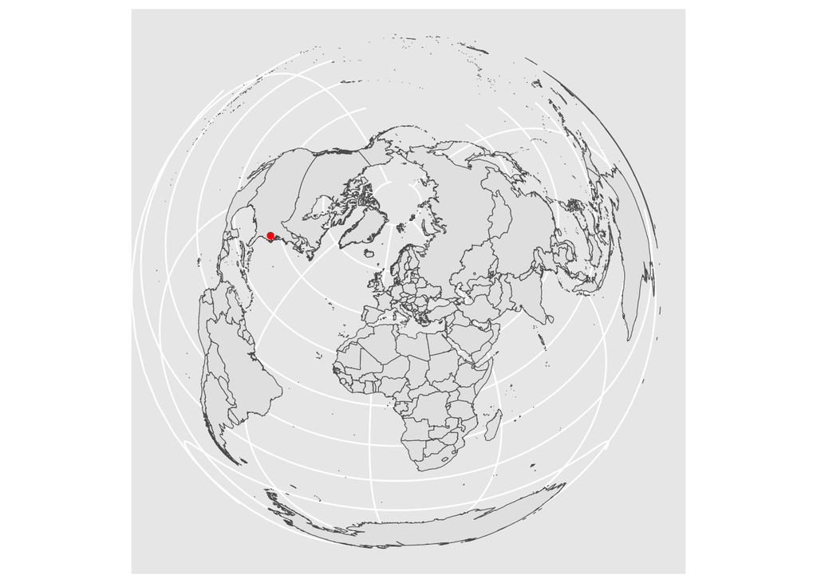

```r
ggplot(data = countries) +
    geom_sf() +
    geom_sf(data = durham_sf, color="red") +
    coord_sf(crs = st_crs("EPSG:3035"))
```

## Chloropleth plots

A chloropleth plot is a map in which the areas or regions are colored with respect to a numerical variable. The Natural Earth country data files include information on population (`POP_EST`) so let’s plot this numerical variable on our map. We’ll also demonstrate how to zoom in on a particular map region (note xlim = longitude limits, ylim = latitude limits)

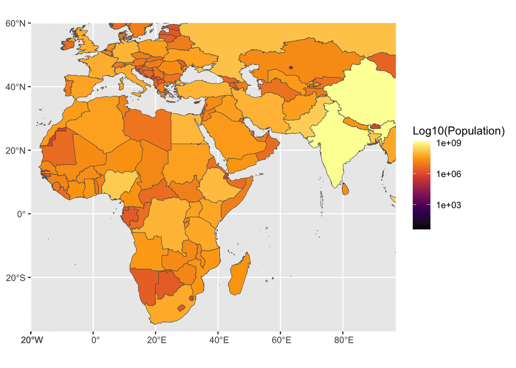

```r
ggplot() +
  geom_sf(data = countries,
          aes(fill = POP_EST)) +
  coord_sf(xlim = c(-20, 97), ylim = c(60, -37), expand = FALSE) +
  scale_fill_viridis_c(option = "inferno", trans = "log10") +
  labs(fill = "Log10(Population)")
```

## Filtering an SF data frame

Let’s load the states/provinces SF file and demonstrate that we can filter the resulting data structures just like any other data frame:

```r
states <-
  st_read("ne_10m_admin_1_states_provinces/ne_10m_admin_1_states_provinces.shp")
```

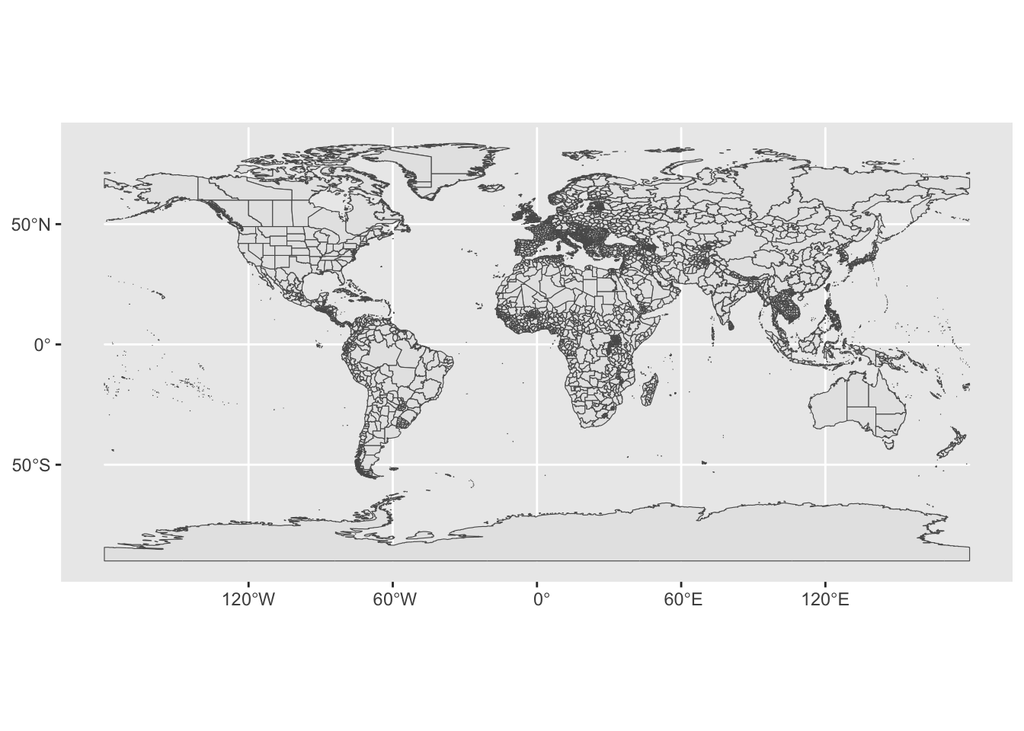

```r
ggplot() +
  geom_sf(data = states) +
  coord_sf()
```

Let’s filter the states data frame to just include those in the United States.

```r
us_states <-
  states |>
  filter(admin == "United States of America")
```

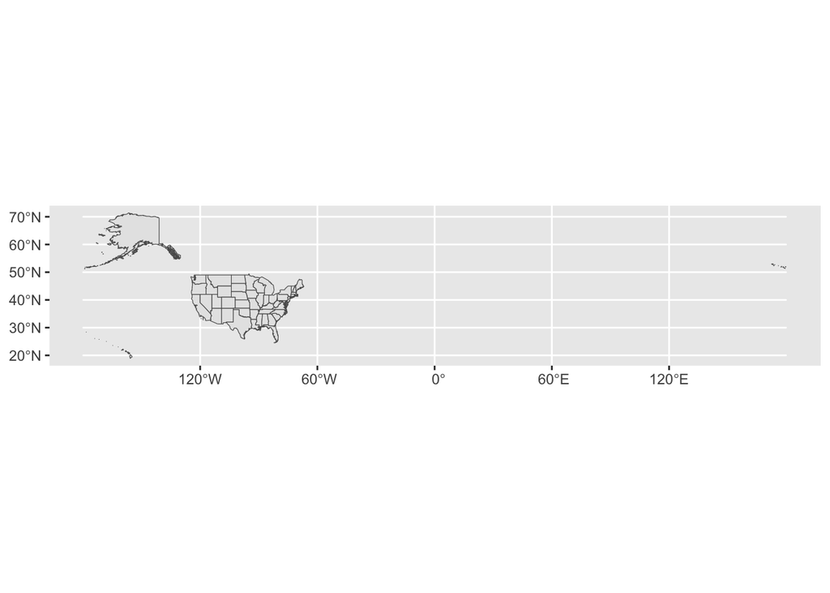

```r
ggplot() +
  geom_sf(data = us_states) +
  coord_sf()
```

That plot looks a little funny (can you figure out why?). Let’s try a different coordinate reference system:

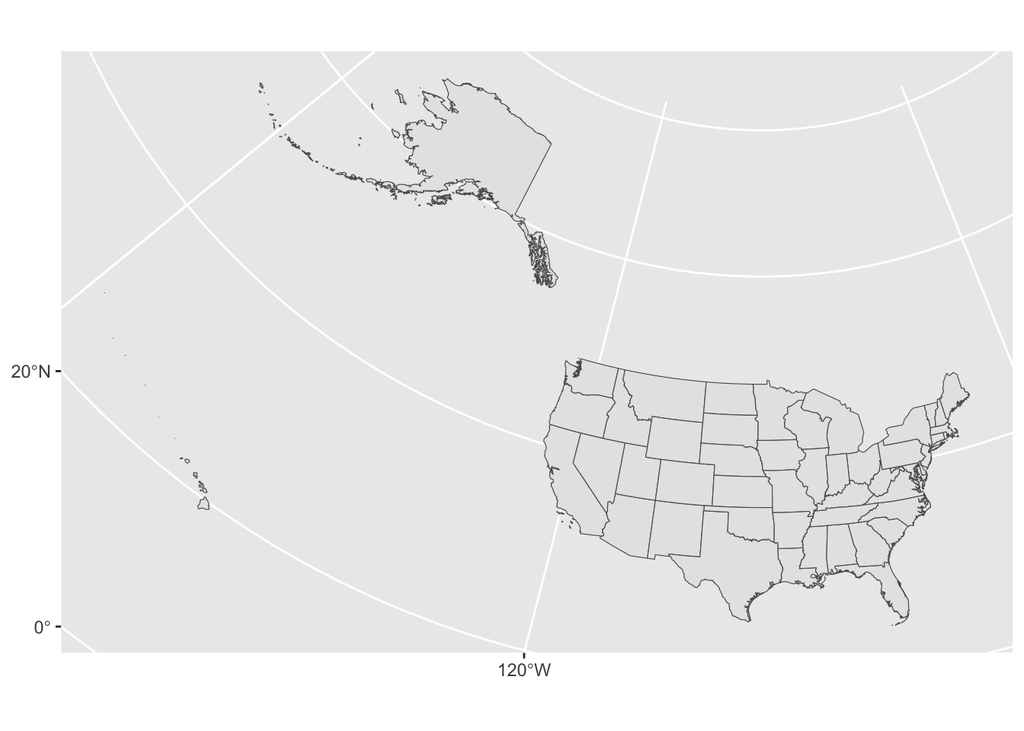

```r
ggplot() +
  geom_sf(data = us_states) +
  coord_sf(crs = st_crs("EPSG:5072"))
```

Let’s further filter the US states to only include those in the continental US and then use patchwork to compare the Mercator projection to an area preserving Albers projection:

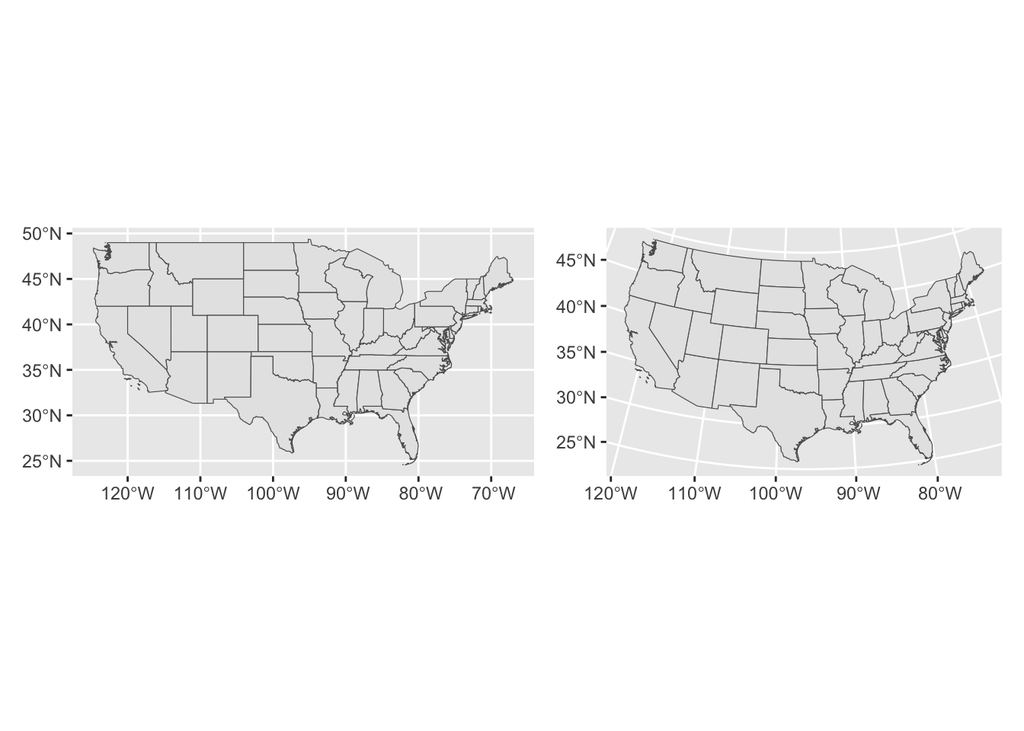

```r
continental_us <-
  us_states |>
  filter(!(name %in% c("Alaska","Hawaii")))

us1 <-
  ggplot() +
  geom_sf(data = continental_us) +
  coord_sf()

us2 <-
  ggplot() +
  geom_sf(data = continental_us) +
  coord_sf(crs = st_crs("EPSG:6350"))

us1 + us2 # layout via patchwork
```

## Zooming in further: US counties and North Carolina

Let’s get even further levels of detail by plotting US county boundaries.

As we did above, we’ll focus on the continental US. In this data, the `REGION` column is what we need to sort on. Besides Hawaii (HI) and Alaska (AK) we also need to filter out Puerto Rico (PR) and the Virgin Islands (VI).

```r
us_counties <-
  st_read("ne_10m_admin_2_counties/ne_10m_admin_2_counties.shp")
continental_counties <-
  us_counties |>
  filter(!(REGION %in% c("AK","HI","PR", "VI")))
```

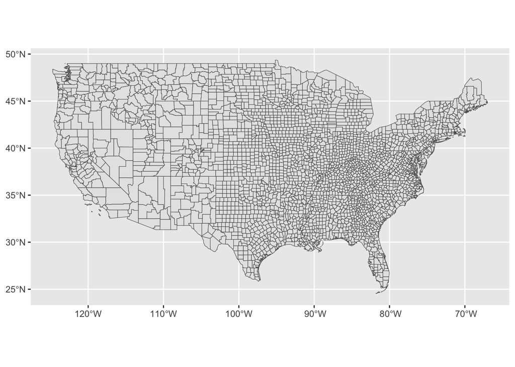

```r
ggplot() +
  geom_sf(data = continental_counties)
```

## Focusing on North Carolina

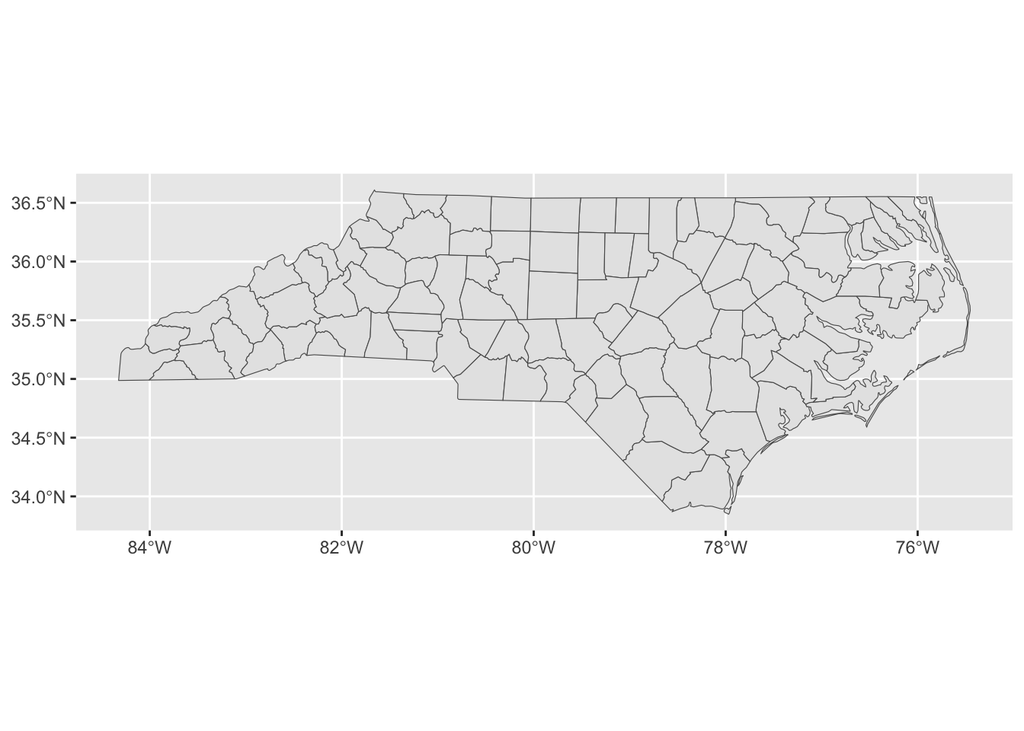

```r
north_carolina <-
  us_counties |>
  filter(REGION == "NC")

ggplot() +
  geom_sf(data = north_carolina)
```

## Plotting localilies on our NC map

As a final example, let’s plot the locations in North Carolina where there have been reported sightings of rare and beautiful North Carolina Blue Snouters.

```r
nc_snouters <-
  read_tsv("https://raw.githubusercontent.com/Bio724D/Bio724D_2024_2025/refs/heads/main/data/nc_snouter_sites.tsv")
head(nc_snouters)
```

```
# A tibble: 6 × 2
  latitude longitude
     <dbl>     <dbl>
1     36.3     -79.4
2     36.0     -79.0
3     36.0     -79.1
4     35.9     -79.0
5     35.9     -78.9
6     35.9     -78.8
```

```r
snouters_sf <-
  st_as_sf(nc_snouters,
           coords = c("longitude","latitude"),
           crs=4326)
```

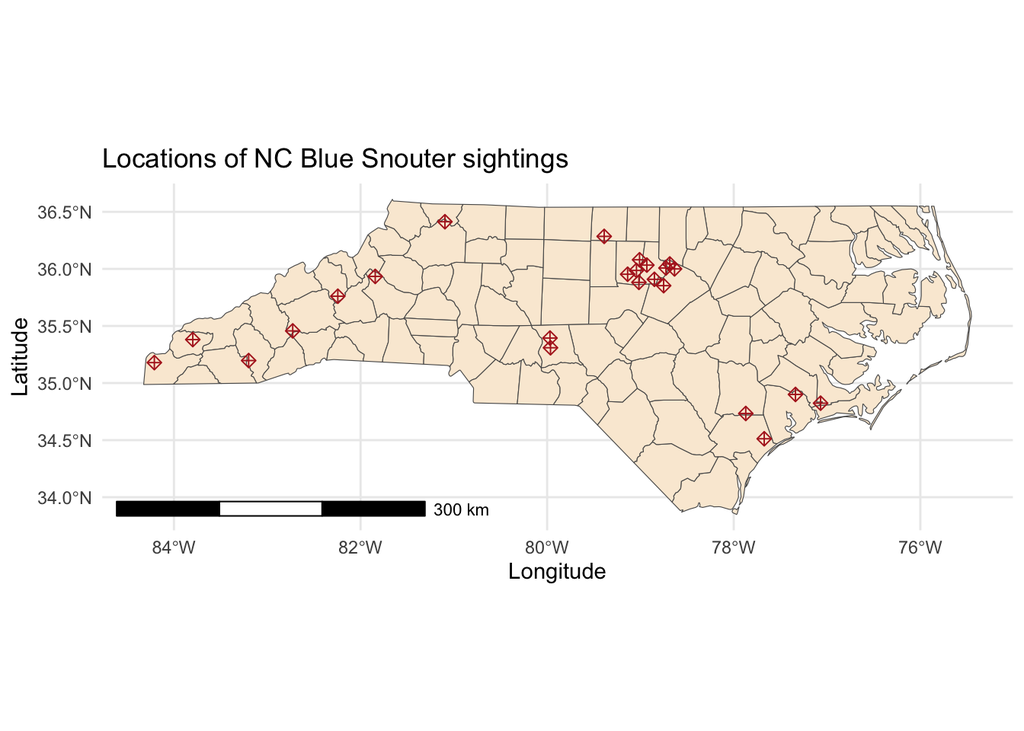

```r
ggplot() +
  geom_sf(data = north_carolina, fill = "antiquewhite") +
  geom_sf(data = snouters_sf,
             color="firebrick",
             size = 2,
             shape = 9) +
  annotation_scale(location = "bl", width_hint = 0.4) +
  labs(title = "Locations of NC Blue Snouter sightings",
       x = "Longitude", y = "Latitude") +
  theme_minimal()
```